# Football Cliches: Derbies & Form

## Introduction

“Form goes out of the windows for a derby,” is one of football’s many cliches. But what does data have to say about it? (All the material for this post can be found [here](https://github.com/gfleetwood/soccer-analytics/tree/master/small_projects/derby-team-form).)

## Methodology

Luckily James Curly’s engsoccerdata library exists, so I didn’t need to web scrape results. Its data actu ally covers a number of European league results, but the above cliche is - as far as I know - distinctly English, so I stuck to that area of the football landscape. The English football results stretch all the way from 1888 to 2017.

I collected rivalry data manually by copy-pasting data from [Wikipedia](https://en.wikipedia.org/wiki/List_of_sports_rivalries_in_the_United_Kingdom#Association_Football). Some cleaning in Excel created a pretty clean data set of 88 English rivalries to work with.

```
##         Date Season                    home              visitor  FT hgoal
## 1 1888-09-08   1888        Bolton Wanderers         Derby County 3-6     3
## 2 1888-09-08   1888                 Everton      Accrington F.C. 2-1     2
## 3 1888-09-08   1888       Preston North End              Burnley 5-2     5
## 4 1888-09-08   1888              Stoke City West Bromwich Albion 0-2     0
## 5 1888-09-08   1888 Wolverhampton Wanderers          Aston Villa 1-1     1
## 6 1888-09-15   1888             Aston Villa           Stoke City 5-1     5
##   vgoal division tier totgoal goaldif result rivalry_id
## 1     6        1    1       9      -3      A         NA
## 2     1        1    1       3       1      H         NA
## 3     2        1    1       7       3      H         NA
## 4     2        1    1       2      -2      A         NA
## 5     1        1    1       2       0      D         NA
## 6     1        1    1       6       4      H         NA
```

```
## # A tibble: 6 x 4
##   rivalry_id team1_match        team2_match         rivalry
##        <int> <chr>              <chr>               <list>
## 1          1 Oxford United      Swindon Town        <chr [2]>
## 2          7 Cambridge United   Peterborough United <chr [2]>
## 3          8 AFC Wimbledon      Milton Keynes Dons  <chr [2]>
## 4         10 Luton Town         Stevenage Borough   <chr [2]>
## 5         11 Luton Town         Watford             <chr [2]>
## 6         12 Milton Keynes Dons Northampton Town    <chr [2]>
```

An important note before the calculations begin. I defined form as the average number of points collected by either team in their five games prior to the derby. This definition was only broken if a derby occured before the sixth match day. I applied a filter to ensure that the calculation only involved games within the same season.

Let me do one rivalry first: Burnley x Blackburn. Matches between the two show up 90 times in the data set. The first game happened in 1888 and finished in a 1-7 away win for Blackburn.

```r
rivalry_indices <- which(eng_results$rivalry_id == 51)
# dataframe of all the results before the derby
df_first_derby <- eng_results[1:(rivalry_indices[1] - 1),]
eng_results[rivalry_indices[1],]
```

```
##          Date Season    home          visitor  FT hgoal vgoal division
## 47 1888-11-03   1888 Burnley Blackburn Rovers 1-7     1     7        1
##    tier totgoal goaldif result rivalry_id
## 47    1       8      -6      A         51
```

Coming into that first derby Blackburn picked up 1.2 points in their five previous games (1-3-1).

```r
df_first_derby %>%
    arrange(desc(Date)) %>%
    filter((home == "Blackburn Rovers") | (visitor == "Blackburn Rovers")) %>%
    top_n(., n = 5, wt = Date) %>%
    filter(Season == max(Season)) %>%
    mutate(
    pts = case_when(
      (home == "Blackburn Rovers") & (hgoal > vgoal) ~ 3,
      (home == "Blackburn Rovers") & (hgoal < vgoal) ~ 0,
      (visitor == "Blackburn Rovers") & (hgoal > vgoal) ~ 0,
      (visitor == "Blackburn Rovers") & (hgoal < vgoal) ~ 3,
      TRUE ~ 1
      )
  ) %>%
  summarise(pts_avg = mean(pts))
```

```
##   pts_avg
## 1     1.2
```

Burnley’s form was worse with only 0.6 points across five games (1-0-4).

```r
df_first_derby %>%
    arrange(desc(Date)) %>%
    filter((home == "Burnley") | (visitor == "Burnley")) %>%
    top_n(., n = 5, wt = Date) %>%
    filter(Season == max(Season)) %>%
    mutate(
    pts = case_when(
      (home == "Burnley") & (hgoal > vgoal) ~ 3,
      (home == "Burnley") & (hgoal < vgoal) ~ 0,
      (visitor == "Burnley") & (hgoal > vgoal) ~ 0,
      (visitor == "Burnley") & (hgoal < vgoal) ~ 3,
      TRUE ~ 1
      )
  ) %>%
  summarise(pts_avg = mean(pts))
```

```
##   pts_avg
## 1     0.6
```

So the first derby not only saw the “form team” win but win emphatically away from home. How does that looks across all the Burnley x Blackburn derbies?

```r
burnley_blackburn <- calculate_derby_form(
  eng_results,
  eng_rivalries[eng_rivalries$rivalry_id==51,]
)

head(burnley_blackburn)
```

```
##         Date Season             home          visitor  FT hgoal vgoal
## 1 1888-11-03   1888          Burnley Blackburn Rovers 1-7     1     7
## 2 1889-02-04   1888 Blackburn Rovers          Burnley 4-2     4     2
## 3 1889-10-26   1889 Blackburn Rovers          Burnley 7-1     7     1
## 4 1890-02-22   1889          Burnley Blackburn Rovers 1-2     1     2
## 5 1890-10-18   1890          Burnley Blackburn Rovers 1-6     1     6
## 6 1890-11-22   1890 Blackburn Rovers          Burnley 5-2     5     2
##   division tier totgoal goaldif result rivalry_id      result_name  rival1
## 1        1    1       8      -6      A         51 Blackburn Rovers Burnley
## 2        1    1       6       2      H         51 Blackburn Rovers Burnley
## 3        1    1       8       6      H         51 Blackburn Rovers Burnley
## 4        1    1       3      -1      A         51 Blackburn Rovers Burnley
## 5        1    1       7      -5      A         51 Blackburn Rovers Burnley
## 6        1    1       7       3      H         51 Blackburn Rovers Burnley
##             rival2 form1 form2        form_team
## 1 Blackburn Rovers   0.6   1.2 Blackburn Rovers
## 2 Blackburn Rovers   2.0   0.8          Burnley
## 3 Blackburn Rovers   0.4   2.0 Blackburn Rovers
## 4 Blackburn Rovers   0.0   0.8 Blackburn Rovers
## 5 Blackburn Rovers   1.4   1.4            Equal
## 6 Blackburn Rovers   1.4   2.4 Blackburn Rovers
```

When there was a clear form team, said team’s record stands at 39-15-28. That’s a ~48% win rate. Breaking this down translates into a 19-9-13 record for Burnley and a 20-6-15 record for Blackburn.

```r
burnley_blackburn %>%
  filter(form_team != "Equal") %>%
  group_by(form_team, result_name) %>%
  count() %>%
  ungroup()
```

```
## # A tibble: 6 x 3
##   form_team        result_name          n
##   <chr>            <chr>            <int>
## 1 Blackburn Rovers Blackburn Rovers    20
## 2 Blackburn Rovers Burnley             15
## 3 Blackburn Rovers D                    6
## 4 Burnley          Blackburn Rovers    13
## 5 Burnley          Burnley             19
## 6 Burnley          D                    9
```

```r
burnley_blackburn %>%
  filter(form_team != "Equal") %>%
  group_by(form_team, result_name) %>%
  count() %>%
  ungroup() %>%
  mutate(
    form_team_abstract  = case_when(
      form_team == result_name ~ "Form Team Won",
      (form_team != result_name) & (result_name!="D") ~ "Form Team Lost",
      TRUE ~ "Form Team Drew"
    )
  ) %>%
  group_by(form_team_abstract) %>%
  summarise(record = sum(n))
```

```
## # A tibble: 3 x 2
##   form_team_abstract record
##   <chr>               <int>
## 1 Form Team Drew         15
## 2 Form Team Lost         28
## 3 Form Team Won          39
```

```r
#abs(burnley_blackburn$form1 - burnley_blackburn$form2) %>% boxplot()
#abs(burnley_blackburn$form1 - burnley_blackburn$form2) %>% fivenum()
```

The cliche looks pretty safe with one derby’s worth of data. Small samples are the enemy of steady conclusions, though, so the results on the entire data set is where the saying will live or die.

```r
# derby_form_eng_nested <- purrrlyr::by_row(
#   eng_rivalries,
#   function(x) calculate_derby_form(eng_results, x)
#   )
# write_rds(derby_form_eng_nested, "derby_form_eng.rds")
```

```r
derby_form_eng_nested <- read_rds("derby_form_eng.rds")
derby_form_eng_unnested <- derby_form_eng_nested %>% unnest(.out)

derby_form_eng_unnested %>%
  filter(form_team != "Equal") %>%
  group_by(form_team, result_name) %>%
  count() %>%
  ungroup() %>%
  mutate(
    form_team_abstract  = case_when(
      form_team == result_name ~ "Form Team Won",
      (form_team != result_name) & (result_name!="D") ~ "Form Team Lost",
      TRUE ~ "Form Team Drew"
    )
  ) %>%
  group_by(form_team_abstract) %>%
  summarise(record = sum(n))
```

```
## # A tibble: 3 x 2
##   form_team_abstract record
##   <chr>               <int>
## 1 Form Team Drew        975
## 2 Form Team Lost       1144
## 3 Form Team Won        1420
```

Lastly, I want to address something that is surely bothering you, reader. There quite a big possible range for form teams. At one end there’s the team with one point in five games coming up against one on a five game losing streak. At the other end the team on a five game losing streak is playing one on a five game winning run.

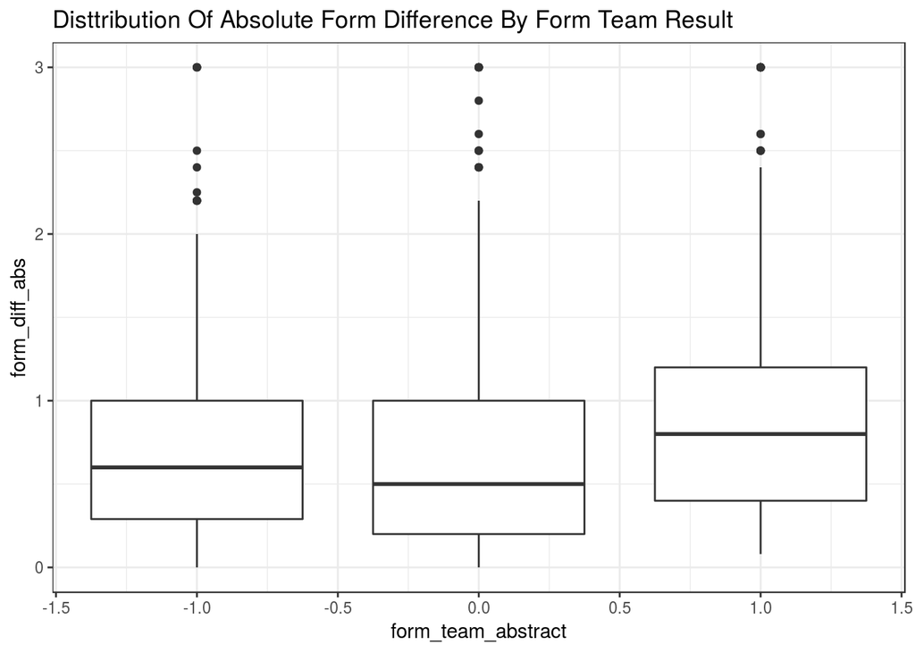

```r
derby_form_eng_unnested <- derby_form_eng_unnested %>%
  mutate(form_diff_abs = abs(form1 - form2))

#derby_form_eng_unnested %>% pull(form_diff_abs) %>% fivenum()
#derby_form_eng_unnested %>% pull(form_diff_abs) %>% boxplot()

derby_form_eng_unnested %>%
  mutate(
    form_team_abstract  = case_when(
      form_team == result_name ~ 1,
      (form_team != result_name) & (result_name!="D") ~ 0,
      TRUE ~ -1
    )
  ) %>%

  ggplot(., aes(form_team_abstract, form_diff_abs)) +
  geom_boxplot(aes(group = form_team_abstract)) + theme_bw() +
    ggtitle("Disttribution Of Absolute Form Difference By Form Team Result")
```

## Conclusion

Does form go out of the window in a derby? The answer is kinda? Unsurprisingly, It all hinges on what the definition of form and form team.

There are a number of ways to add nuance to this analysis, The primary one that jumps out is dissecting results by home and away. That data is present here, but I declined to go in that direction because I felt it was against the spirit of the cliche being inspected.

And it is in this spirit that I chalk this up as a soft win for the real football men.